# Technical Analysis using R — Preliminary Stage

BDA400 Data Science Tools and Techniques · Assignment 2

Viktoriia Agafonova

November 18, 2026

> **AI Assistance Declaration:** I used Claude (Anthropic, Claude Opus 5.5, Claude desktop app, 2026-11-18) for drafting the structure of the functions, this R Markdown layout and comments. I verified outputs by running and knitting the code in RStudio and checking the tables against the downloaded data. All final calculations are done by R. I am responsible for the accuracy and originality of this work.

# 1 Project configuration

The portfolio is defined in **`portfolio.txt`** — one ticker symbol per line.

```r
portfolio_file <- "portfolio.txt"
cat(readLines(portfolio_file), sep = "\n")
```

```
## AAPL
## MSFT
## GOOGL
## AMZN
## NVDA
```

```r
symbols <- read_portfolio(portfolio_file)
symbols
```

```
## [1] "AAPL"  "MSFT"  "GOOGL" "AMZN"  "NVDA"
```

Analysis period (daily data from Yahoo Finance via `quantmod`):

```r
start_date <- as.Date("2025-11-01")
end_date   <- as.Date("2026-11-01")   # 'to' is exclusive in getSymbols()
ma_windows <- c(20, 50)               # moving-average windows (trading days)
```

# 2 Importing stock data

`load_stock_data()` reads `portfolio.txt`, downloads the data for every symbol with `quantmod::getSymbols()` and returns **one data frame per symbol** (columns: Date, Open, High, Low, Close, Volume, Adjusted). With `assign_to_env = TRUE` it also creates a separate data frame named after each symbol (e.g. `AAPL`).

```r
stocks <- load_stock_data(portfolio_file, from = start_date, to = end_date,
                          assign_to_env = TRUE)
vapply(stocks, nrow, integer(1))   # trading days loaded per symbol
```

```
##  AAPL  MSFT GOOGL  AMZN  NVDA
##   250   250   250   250   250
```

```r
str(stocks[[1]])
```

```
## 'data.frame':    250 obs. of  7 variables:
##  $ Date    : Date, format: "2025-11-03" "2025-11-04" ...
##  $ Open    : num  270 268 269 268 270 ...
##  $ High    : num  271 271 272 273 272 ...
##  $ Low     : num  266 268 267 268 267 ...
##  $ Close   : num  269 270 270 270 268 ...
##  $ Volume  : num  50194600 49274800 43683100 51204000 48227400 ...
##  $ Adjusted: num  268 269 269 269 267 ...
```

# 3 Computing statistics

`calculate_statistics()` takes one stock’s data frame and computes, on the **Close** price:

- **Mean**, **median**, **standard deviation** (base R);
- **Mode** — prices are continuous, so they are rounded to whole dollars before counting the most frequent value (`get_mode()`);
- **Simple moving averages** of 20 and 50 days (`TTR::SMA()`);
- extra context: min, max, last close, mean daily return and daily volatility.

Results are stored in a structured list: a one-row `summary` data frame and a `moving_averages` data frame for each stock. `calculate_all_statistics()` applies it to the whole portfolio.

```r
results <- calculate_all_statistics(stocks, price_col = "Close", ma_windows = ma_windows)
str(results$by_symbol[[1]], max.level = 1)
```

```
## List of 2
##  $ summary        :'data.frame': 1 obs. of  14 variables:
##  $ moving_averages:'data.frame': 250 obs. of  4 variables:
```

## 3.1 Portfolio summary

```r
kable(results$summary_table[, c("Symbol", "Observations", "Mean", "Median", "Mode",
                                "Std_Dev", "Min", "Max", "Last_Close",
                                "Last_SMA_20", "Last_SMA_50")],
      digits = 2, format.args = list(big.mark = ","),
      col.names = c("Symbol", "Days", "Mean", "Median", "Mode", "Std. dev.",
                    "Min", "Max", "Last close", "SMA 20", "SMA 50"),
      caption = "Table 1. Close-price statistics by stock (USD)")
```

Table 1. Close-price statistics by stock (USD)

| Symbol | Days | Mean | Median | Mode | Std. dev. | Min | Max | Last close | SMA 20 | SMA 50 |
| --- | --- | --- | --- | --- | --- | --- | --- | --- | --- | --- |
| AAPL | 250 | 291.65 | 283.44 | 273 | 29.65 | 246.63 | 348.91 | 344.63 | 342.08 | 333.04 |
| MSFT | 250 | 447.77 | 450.67 | 487 | 52.35 | 352.83 | 543.45 | 521.91 | 530.98 | 512.91 |
| GOOGL | 250 | 333.99 | 336.36 | 344 | 28.84 | 273.50 | 402.62 | 279.84 | 333.91 | 339.07 |
| AMZN | 250 | 241.50 | 244.40 | 250 | 19.64 | 198.79 | 284.02 | 240.35 | 254.39 | 254.28 |
| NVDA | 250 | 200.55 | 198.93 | 183 | 17.53 | 165.17 | 239.24 | 204.64 | 221.46 | 221.75 |

```r
kable(results$summary_table[, c("Symbol", "Mean_Daily_Return_pct", "Volatility_pct")],
      digits = 3,
      col.names = c("Symbol", "Mean daily return (%)", "Daily volatility (%)"),
      caption = "Table 2. Daily return and volatility")
```

Table 2. Daily return and volatility

| Symbol | Mean daily return (%) | Daily volatility (%) |
| --- | --- | --- |
| AAPL | 0.111 | 1.523 |
| MSFT | 0.025 | 2.075 |
| GOOGL | 0.017 | 2.135 |
| AMZN | 0.000 | 2.107 |
| NVDA | 0.023 | 2.360 |

# 4 Displaying the data

## 4.1 Console-style display utilities

The display functions are designed for the R console; here is their output for the first stock in the portfolio.

```r
first <- names(stocks)[1]
display_stock_data(stocks[[first]], first, n = 5)
```

```
## ======================================================================
## AAPL  |  250 trading days  |  2025-11-03 to 2026-10-30
## ======================================================================
## First 5 rows:
##        Date   Open   High    Low  Close   Volume Adjusted
##  2025-11-03 270.42 270.85 266.25 269.05 50194600 267.8562
##  2025-11-04 268.33 271.49 267.62 270.04 49274800 268.8419
##  2025-11-05 268.61 271.70 266.93 270.14 43683100 268.9415
##  2025-11-06 267.89 273.40 267.89 269.77 51204000 268.5730
##  2025-11-07 269.80 272.29 266.77 268.47 48227400 267.2789
##
## Last 5 rows:
##        Date   Open   High    Low  Close   Volume Adjusted
##  2026-10-26 343.92 347.09 341.03 343.91 42743600 343.6489
##  2026-10-27 343.17 347.78 342.39 347.10 39984400 346.8365
##  2026-10-28 346.92 347.18 343.52 343.83 35714300 343.5689
##  2026-10-29 348.00 351.43 347.30 348.91 42582100 348.6451
##  2026-10-30 346.72 349.19 334.35 344.63 67841600 344.3683
```

```r
display_quote_summary(stocks[[first]], first)
```

```
##
## AAPL quote summary (as of 2026-10-30)
##  Field          Value
##  Last close     344.63
##  Change         -4.28 (-1.23%)
##  Previous close 348.91
##  Open           346.72
##  Day's range    334.35 - 349.19
##  Period range   243.42 - 351.73
##  Volume         67,841,600
##  Avg. volume    47,597,788
```

```r
display_statistics(results$by_symbol[[first]], first)
```

```
##
## Statistics for AAPL (Close price)
##  Statistic             Value
##  Observations          250
##  Start                 2025-11-03
##  End                   2026-10-30
##  Mean                  291.65
##  Median                283.44
##  Mode                  273.00
##  Std Dev               29.65
##  Min                   246.63
##  Max                   348.91
##  Last Close            344.63
##  Mean Daily Return pct 0.11
##  Volatility pct        1.52
##  Last SMA 20           342.08
##  Last SMA 50           333.04
```

## 4.2 Portfolio overview

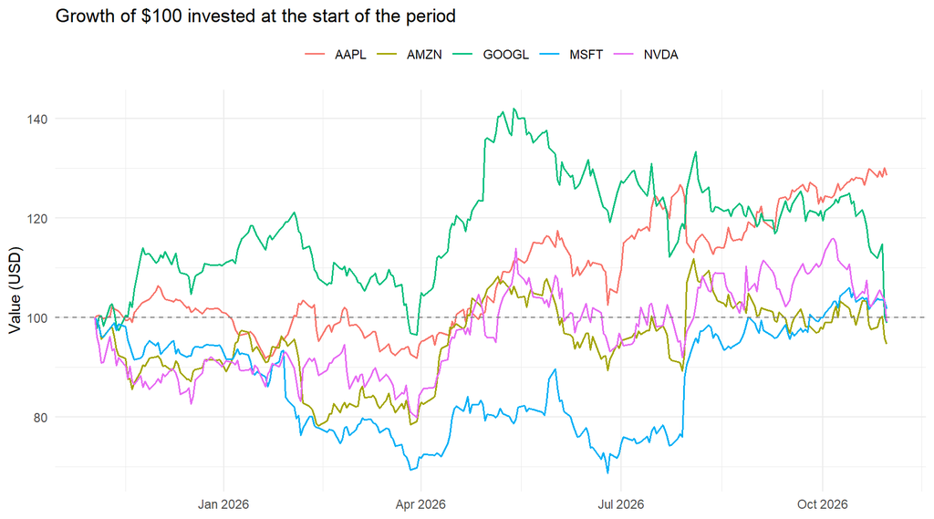

Figure 1. Growth of $100 invested at the start of the period

```r
plot_portfolio_growth(stocks)
```

## 4.3 Stock-by-stock

```r
for (sym in names(stocks)) {
  df    <- stocks[[sym]]
  stats <- results$by_symbol[[sym]]

  cat("\n\n### ", sym, "\n\n", sep = "")

  cat("**Quote summary**\n\n")
  print(kable(build_quote_summary(df), col.names = c("", "")))

  cat("\n\n**Latest 5 trading days**\n\n")
  print(kable(tail(df, 5), digits = 2, row.names = FALSE,
              format.args = list(big.mark = ",")))

  cat("\n\n**Statistics (Close price)**\n\n")
  print(kable(statistics_table(stats)))

  cat("\n\n")
  plot_stock_chart(df, sym)
  cat("\n\n")
  print(plot_price_with_ma(stats, sym))
  cat("\n\n")
}
```

### 4.3.1 AAPL

**Quote summary**

| Last close | 344.63 |
| --- | --- |
| Change | -4.28 (-1.23%) |
| Previous close | 348.91 |
| Open | 346.72 |
| Day’s range | 334.35 - 349.19 |
| Period range | 243.42 - 351.73 |
| Volume | 67,841,600 |
| Avg. volume | 47,597,788 |

**Latest 5 trading days**

| Date | Open | High | Low | Close | Volume | Adjusted |
| --- | --- | --- | --- | --- | --- | --- |
| 2026-10-26 | 343.92 | 347.09 | 341.03 | 343.91 | 42,743,600 | 343.65 |
| 2026-10-27 | 343.17 | 347.78 | 342.39 | 347.10 | 39,984,400 | 346.84 |
| 2026-10-28 | 346.92 | 347.18 | 343.52 | 343.83 | 35,714,300 | 343.57 |
| 2026-10-29 | 348.00 | 351.43 | 347.30 | 348.91 | 42,582,100 | 348.65 |
| 2026-10-30 | 346.72 | 349.19 | 334.35 | 344.63 | 67,841,600 | 344.37 |

**Statistics (Close price)**

| Statistic | Value |
| --- | --- |
| Observations | 250 |
| Start | 2025-11-03 |
| End | 2026-10-30 |
| Mean | 291.65 |
| Median | 283.44 |
| Mode | 273.00 |
| Std Dev | 29.65 |
| Min | 246.63 |
| Max | 348.91 |
| Last Close | 344.63 |
| Mean Daily Return pct | 0.11 |
| Volatility pct | 1.52 |
| Last SMA 20 | 342.08 |
| Last SMA 50 | 333.04 |

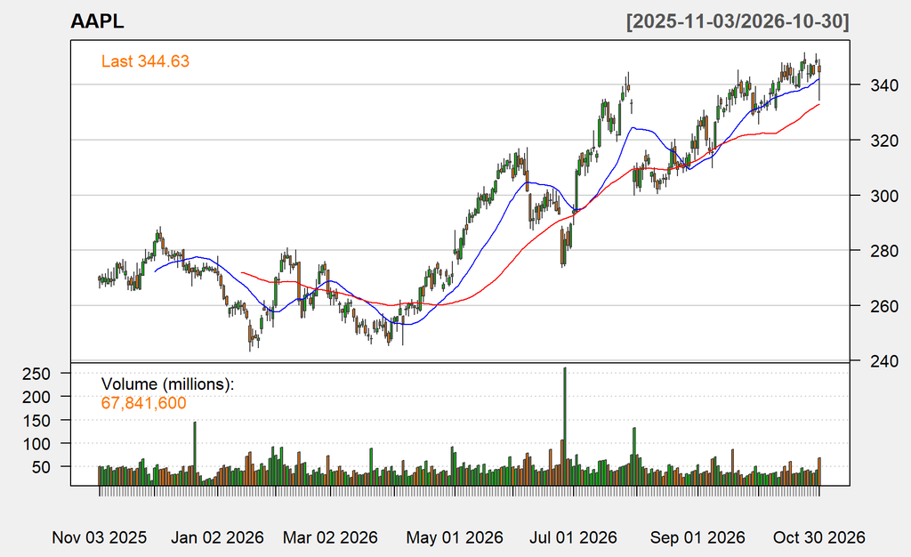

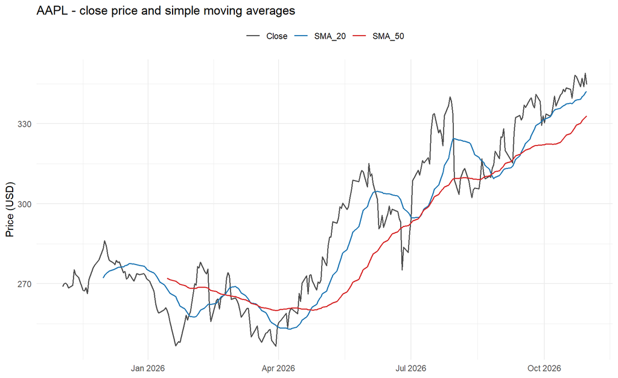

### 4.3.2 MSFT

**Quote summary**

| Last close | 521.91 |
| --- | --- |
| Change | -8.23 (-1.55%) |
| Previous close | 530.14 |
| Open | 525.27 |
| Day’s range | 514.35 - 526.00 |
| Period range | 349.20 - 551.15 |
| Volume | 35,652,000 |
| Avg. volume | 31,908,808 |

**Latest 5 trading days**

| Date | Open | High | Low | Close | Volume | Adjusted |
| --- | --- | --- | --- | --- | --- | --- |
| 2026-10-26 | 527.40 | 533.25 | 521.69 | 532.60 | 19,021,000 | 532.60 |
| 2026-10-27 | 532.35 | 534.70 | 528.33 | 531.33 | 19,532,300 | 531.33 |
| 2026-10-28 | 531.82 | 535.00 | 526.14 | 531.01 | 28,594,200 | 531.01 |
| 2026-10-29 | 540.22 | 541.29 | 519.56 | 530.14 | 39,333,200 | 530.14 |
| 2026-10-30 | 525.27 | 526.00 | 514.35 | 521.91 | 35,652,000 | 521.91 |

**Statistics (Close price)**

| Statistic | Value |
| --- | --- |
| Observations | 250 |
| Start | 2025-11-03 |
| End | 2026-10-30 |
| Mean | 447.77 |
| Median | 450.67 |
| Mode | 487.00 |
| Std Dev | 52.35 |
| Min | 352.83 |
| Max | 543.45 |
| Last Close | 521.91 |
| Mean Daily Return pct | 0.02 |
| Volatility pct | 2.07 |
| Last SMA 20 | 530.98 |
| Last SMA 50 | 512.91 |

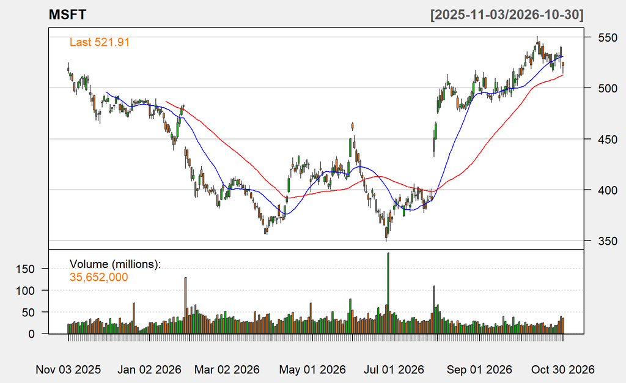

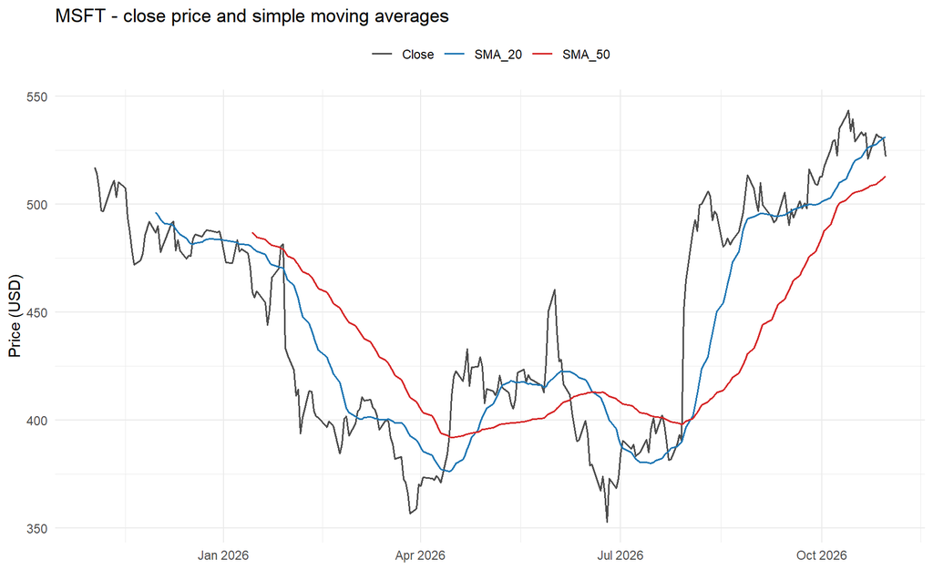

### 4.3.3 GOOGL

**Quote summary**

| Last close | 279.84 |
| --- | --- |
| Change | -3.98 (-1.40%) |
| Previous close | 283.82 |
| Open | 281.12 |
| Day’s range | 276.92 - 283.14 |
| Period range | 270.70 - 408.61 |
| Volume | 65,695,000 |
| Avg. volume | 32,174,376 |

**Latest 5 trading days**

| Date | Open | High | Low | Close | Volume | Adjusted |
| --- | --- | --- | --- | --- | --- | --- |
| 2026-10-26 | 320.89 | 321.48 | 316.60 | 316.80 | 23,991,800 | 316.80 |
| 2026-10-27 | 317.00 | 323.88 | 316.86 | 320.58 | 28,633,100 | 320.58 |
| 2026-10-28 | 323.77 | 326.41 | 322.66 | 324.89 | 63,109,000 | 324.89 |
| 2026-10-29 | 286.88 | 288.33 | 280.36 | 283.82 | 139,738,300 | 283.82 |
| 2026-10-30 | 281.12 | 283.14 | 276.92 | 279.84 | 65,695,000 | 279.84 |

**Statistics (Close price)**

| Statistic | Value |
| --- | --- |
| Observations | 250 |
| Start | 2025-11-03 |
| End | 2026-10-30 |
| Mean | 333.99 |
| Median | 336.36 |
| Mode | 344.00 |
| Std Dev | 28.84 |
| Min | 273.50 |
| Max | 402.62 |
| Last Close | 279.84 |
| Mean Daily Return pct | 0.02 |
| Volatility pct | 2.13 |
| Last SMA 20 | 333.91 |
| Last SMA 50 | 339.07 |

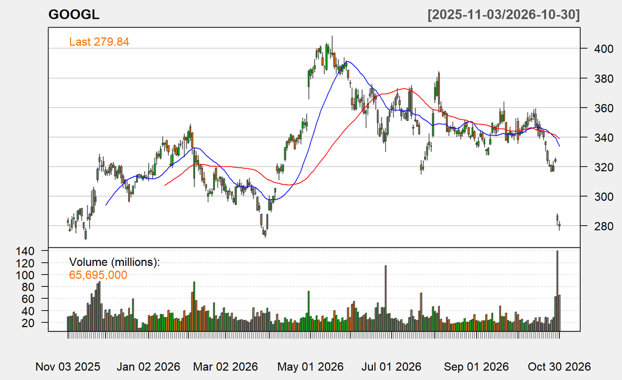

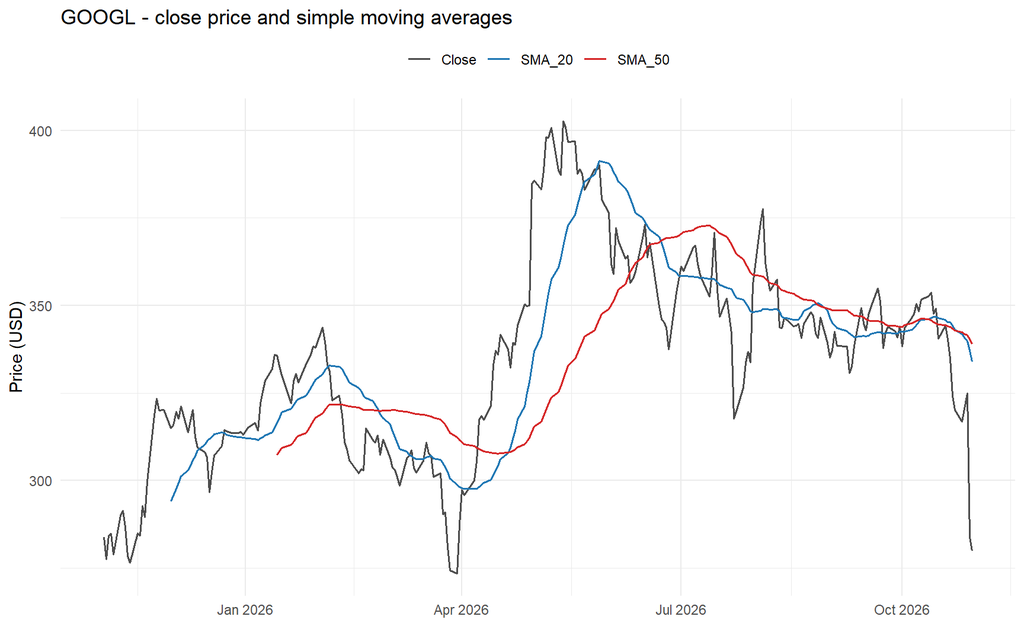

### 4.3.4 AMZN

**Quote summary**

| Last close | 240.35 |
| --- | --- |
| Change | -3.44 (-1.41%) |
| Previous close | 243.79 |
| Open | 232.54 |
| Day’s range | 229.36 - 241.55 |
| Period range | 196.00 - 287.20 |
| Volume | 104,894,700 |
| Avg. volume | 45,525,566 |

**Latest 5 trading days**

| Date | Open | High | Low | Close | Volume | Adjusted |
| --- | --- | --- | --- | --- | --- | --- |
| 2026-10-26 | 249.47 | 250.79 | 247.23 | 249.09 | 32,696,400 | 249.09 |
| 2026-10-27 | 250.43 | 254.68 | 248.71 | 253.10 | 34,477,800 | 253.10 |
| 2026-10-28 | 253.00 | 255.36 | 251.98 | 254.60 | 34,915,900 | 254.60 |
| 2026-10-29 | 246.95 | 249.14 | 241.24 | 243.79 | 85,234,400 | 243.79 |
| 2026-10-30 | 232.54 | 241.55 | 229.36 | 240.35 | 104,894,700 | 240.35 |

**Statistics (Close price)**

| Statistic | Value |
| --- | --- |
| Observations | 250 |
| Start | 2025-11-03 |
| End | 2026-10-30 |
| Mean | 241.50 |
| Median | 244.40 |
| Mode | 250.00 |
| Std Dev | 19.64 |
| Min | 198.79 |
| Max | 284.02 |
| Last Close | 240.35 |
| Mean Daily Return pct | 0.00 |
| Volatility pct | 2.11 |
| Last SMA 20 | 254.39 |
| Last SMA 50 | 254.28 |

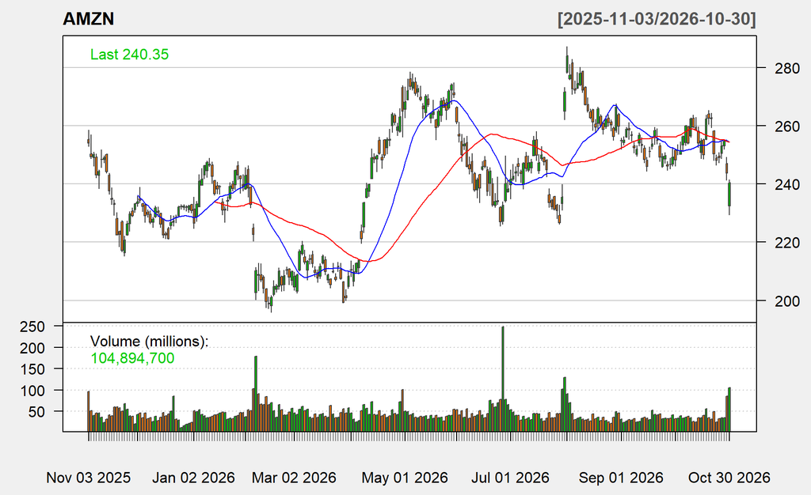

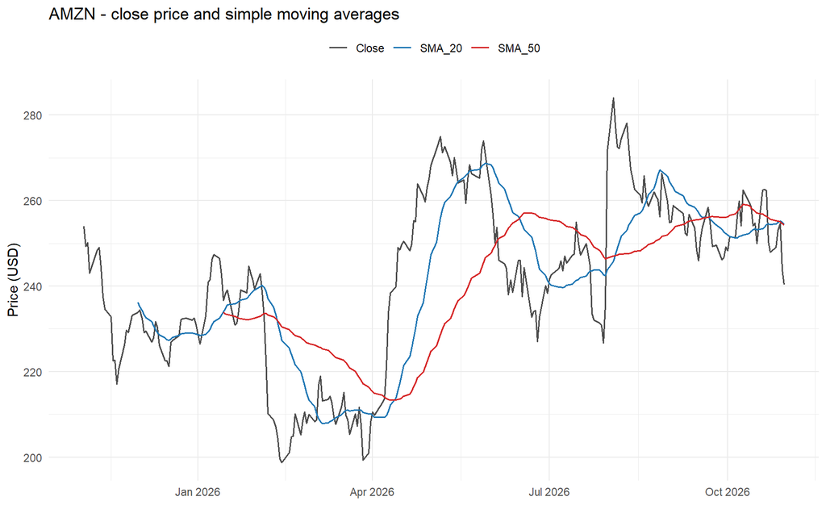

### 4.3.5 NVDA

**Quote summary**

| Last close | 204.64 |
| --- | --- |
| Change | -9.02 (-4.22%) |
| Previous close | 213.66 |
| Open | 208.94 |
| Day’s range | 200.92 - 209.06 |
| Period range | 164.27 - 243.37 |
| Volume | 168,386,400 |
| Avg. volume | 155,563,318 |

**Latest 5 trading days**

| Date | Open | High | Low | Close | Volume | Adjusted |
| --- | --- | --- | --- | --- | --- | --- |
| 2026-10-26 | 213.11 | 217.75 | 212.61 | 216.00 | 90,829,300 | 216.00 |
| 2026-10-27 | 218.31 | 219.19 | 215.53 | 217.94 | 84,799,700 | 217.94 |
| 2026-10-28 | 219.92 | 219.99 | 214.47 | 215.38 | 93,030,200 | 215.38 |
| 2026-10-29 | 214.36 | 215.33 | 212.08 | 213.66 | 77,568,100 | 213.66 |
| 2026-10-30 | 208.94 | 209.06 | 200.92 | 204.64 | 168,386,400 | 204.64 |

**Statistics (Close price)**

| Statistic | Value |
| --- | --- |
| Observations | 250 |
| Start | 2025-11-03 |
| End | 2026-10-30 |
| Mean | 200.55 |
| Median | 198.93 |
| Mode | 183.00 |
| Std Dev | 17.53 |
| Min | 165.17 |
| Max | 239.24 |
| Last Close | 204.64 |
| Mean Daily Return pct | 0.02 |
| Volatility pct | 2.36 |
| Last SMA 20 | 221.46 |
| Last SMA 50 | 221.75 |

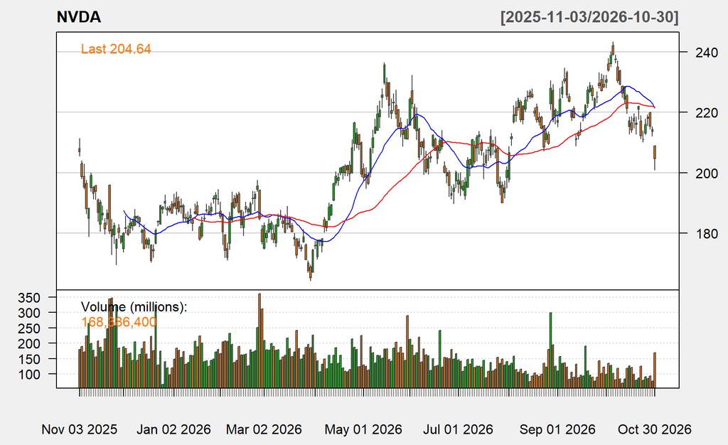

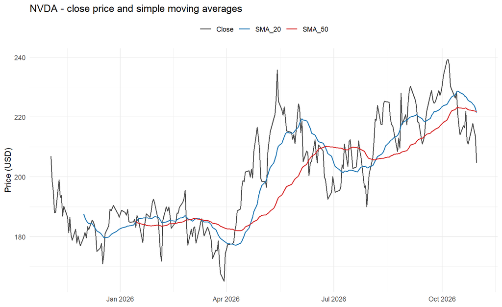